# Report: act_report

## WeRateDogs Twitter Analysis and Visualization Report

## WeRateDogs Twitter Analysis

**A little dive into WeRateDogs twitter account**

WeRateDogs is a Twitter account that rates people's dogs with a humorous comment about the dog. These ratings almost always have a denominator of 10. The numerators, though? Almost always greater than 10. 11/10, 12/10, 13/10, etc. Why? Because "they're good dogs Brent." WeRateDogs has over 4 million followers and has received international media coverage.

I performed data wrangling process on WeRateDogs Twitter archive which in turn yeid a master dataset called twitter_archive_master.csv.

With this twitter_archive_master.csv I carried out my analysis and visualizations.

I was able to uncover about 3 interesting insights from my analysis.

### 1. Dogs with top favourite count with their corresponding tweet_id

#### Analysis and Visualization

I analysed the first 10 top dogs with highest favorite_count along side with their names and tweet_id from which I was able to fetch out the Dog with top favourite count with the tweet_id.

My analysis shows that 3 dog with name **Duddles**, **Stephan** and **Jamesy** with tweet_id **879415818425184262**, **807106840509214720** and **866450705531457537** respectively has a really close favorite_count.

- Duddles has the highest favorite_count of **107956.0**
- Stephan has favorite_count of **107015.0**
- Jamesy has favorite_count of **106827.0**

But based on my analysis, **Duddles** with tweet_id **879415818425184262** has the highest favorite_count of **107956.0**

#### visual representation

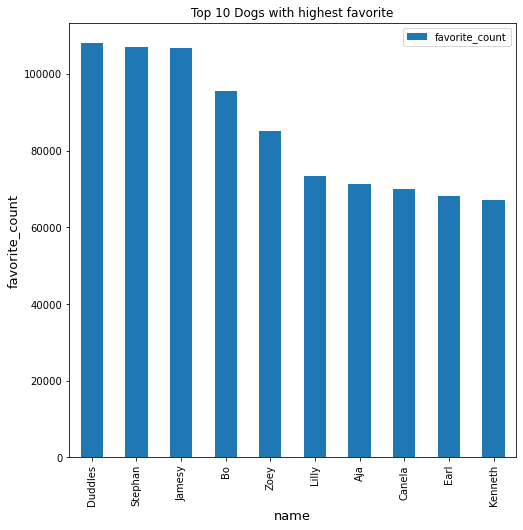

### 2. Dog stages with top favourite count and retweet_count

#### visual representation

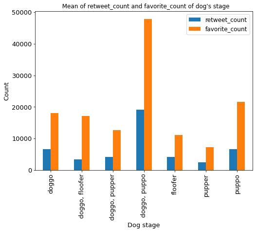

The display above shows the mean favorite_count and retweet_count of dog stages.

### 3. year with the highest favorite count and the Dog who had the win

#### Analysis and Visualization

My analysis shows that the year 2017 has highest favorite_count of **107956.0** Dog with name **Duddles**

##### visual representation

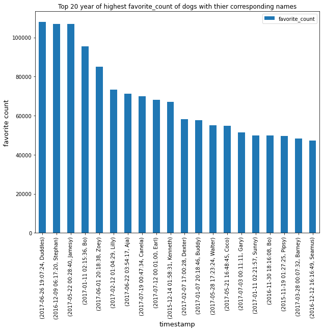

The display above shows 20 top year of highest favorite_count with ther corresponding dog name.